# PPOL670 | Supervised Learning - Classification

Walkthrough

Week 10

# Overview

In this notebook, we’ll apply the machine learning concepts covered in the classification supervised learning lecture. Note that there are many libraries that can perform the methods that we reviewed in class, but we’ll focus here on using the `caret` package to perform these operations.

```r
require(tidyverse)
require(caret) # for machine learning
require(recipes) # For preprocessing your data
require(rattle) # For nice tree plots

# For parallelization (to run the models across many cores) -- speeds up computation!
# install.packages("doMC")
doMC::registerDoMC()
```

# Data

The following data contains information regarding whether or not someone has health coverage. The outcome of interest is whether of not an individual has healthcare coverage or not. The available predictive features capture socio-economic and descriptive factors.

```r
set.seed(123)
dat = suppressMessages(read_csv("health-coverage.csv")) %>%
  sample_n(5000) # Only taking a random sample of the data so the models run quicker
head(dat) # Peek at the data just to make sure everything was read in correctly.
```

```
## # A tibble: 6 x 7
##   coverage      age   wage cit        mar          educ               race
##   <chr>       <int>  <int> <chr>      <chr>        <chr>              <chr>
## 1 No_Coverage    26  14500 Citizen    Married      HS Degree          White
## 2 Coverage       36 120000 Non-citiz… Married      Undergraduate Deg… White
## 3 No_Coverage    42      0 Citizen    Never Marri… HS Degree          Black
## 4 Coverage       61  61000 Citizen    Married      HS Degree          White
## 5 Coverage       74      0 Citizen    Divorced     HS Degree          White
## 6 No_Coverage    36  25000 Citizen    Married      HS Degree          White
```

# Split the Sample: Training and test data

Before event looking at the data, let’s split the sample up into a training and test dataset. We’ll completely hold off on viewing the test data, so as not to bias our development of the learning model.

```r
index = createDataPartition(dat$coverage,p=.8,list=F)
train_data = dat[index,] # Use 80% of the data as training data
test_data = dat[-index,] # holdout 20% as test data

dim(train_data)
```

```
## [1] 4001    7
```

```r
dim(test_data)
```

```
## [1] 999   7
```

# Examine the data

```r
skimr::skim(train_data)
```

```
## Skim summary statistics
##  n obs: 4001
##  n variables: 7
##
## ── Variable type:character ────────────────────────────────────────────────────────────
##  variable missing complete    n min max empty n_unique
##       cit       0     4001 4001   7  11     0        2
##  coverage       0     4001 4001   8  11     0        2
##      educ       0     4001 4001   9  20     0        4
##       mar       0     4001 4001   7  13     0        5
##      race       0     4001 4001   5  23     0        8
##
## ── Variable type:integer ──────────────────────────────────────────────────────────────
##  variable missing complete    n     mean       sd p0 p25  p50   p75   p100
##       age       0     4001 4001    43.66    17.26 16  29   43    56     92
##      wage       0     4001 4001 20495.15 39825.55  0   0 4800 28000 419000
##      hist
##  ▇▇▆▇▆▃▂▁
##  ▇▁▁▁▁▁▁▁
```

Visualize the distribution for each variable.

First, let’s look at the categorical variables.

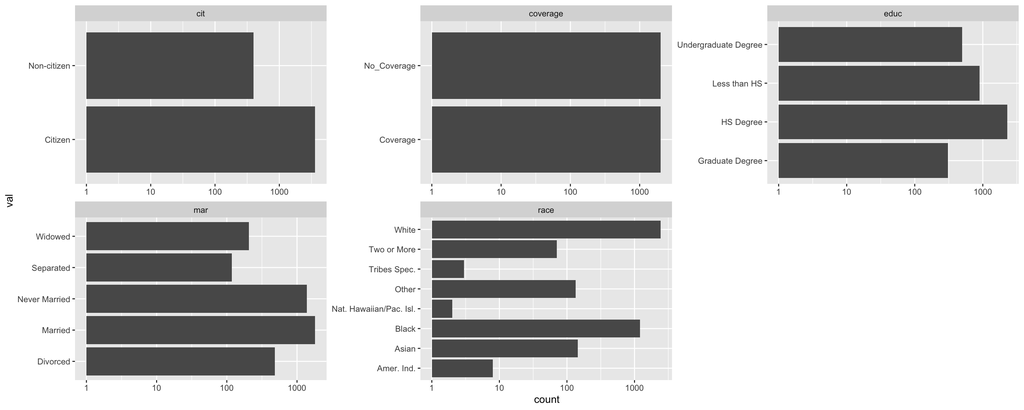

```r
train_data %>%
  select_if(is.character) %>%
  gather(var,val) %>%
  ggplot(aes(val)) +
  geom_bar() +
  scale_y_log10() +
  facet_wrap(~var,scales="free",ncol=3) +
  coord_flip()
```

Few things to note:

- Balanced classes on the outcome
- Over representativeness of some racial groups in the data.
- Good variation on maritial outcomes and education

Let’s peek at the data a little closer. We see that there are potential issues in this data with **perfect prediction**. That is, among some categorical configurations, there lie arrangements where there is no variation in the outcome. For these instances, we can predict Coverage or lack there of perfectly. This can cause issues for some models (logistic regression, SVM).

```r
train_data %>%
  select_if(is.character) %>%
  group_by_all() %>%
  count() %>%
  spread(coverage,n,fill=0) %>%
  arrange(Coverage)
```

```
## # A tibble: 141 x 6
## # Groups:   cit, mar, educ, race [141]
##    cit     mar          educ               race        Coverage No_Coverage
##    <chr>   <chr>        <chr>              <chr>          <dbl>       <dbl>
##  1 Citizen Divorced     Graduate Degree    Two or More        0           1
##  2 Citizen Divorced     HS Degree          Other              0           3
##  3 Citizen Divorced     Less than HS       Asian              0           1
##  4 Citizen Divorced     Undergraduate Deg… Amer. Ind.         0           1
##  5 Citizen Divorced     Undergraduate Deg… Two or More        0           1
##  6 Citizen Married      HS Degree          Amer. Ind.         0           1
##  7 Citizen Married      Undergraduate Deg… Other              0           1
##  8 Citizen Never Marri… Less than HS       Amer. Ind.         0           1
##  9 Citizen Never Marri… Undergraduate Deg… Tribes Spe…        0           1
## 10 Citizen Separated    Graduate Degree    Black              0           1
## # … with 131 more rows
```

For these models, we might need to restict the types of variables we use as to not run into issues.

```r
train_data %>%
  select(-race,-mar) %>%
  select_if(is.character) %>%
  group_by_all() %>%
  count() %>%
  spread(coverage,n,fill=0) %>%
  arrange(Coverage)
```

```
## # A tibble: 8 x 4
## # Groups:   cit, educ [8]
##   cit         educ                 Coverage No_Coverage
##   <chr>       <chr>                   <dbl>       <dbl>
## 1 Non-citizen Graduate Degree            11          11
## 2 Non-citizen Less than HS               14         183
## 3 Non-citizen Undergraduate Degree       19          18
## 4 Non-citizen HS Degree                  24         115
## 5 Citizen     Graduate Degree           242          44
## 6 Citizen     Less than HS              264         440
## 7 Citizen     Undergraduate Degree      335         124
## 8 Citizen     HS Degree                1094        1063
```

Second, let’s look at the distribution of the continuous variables

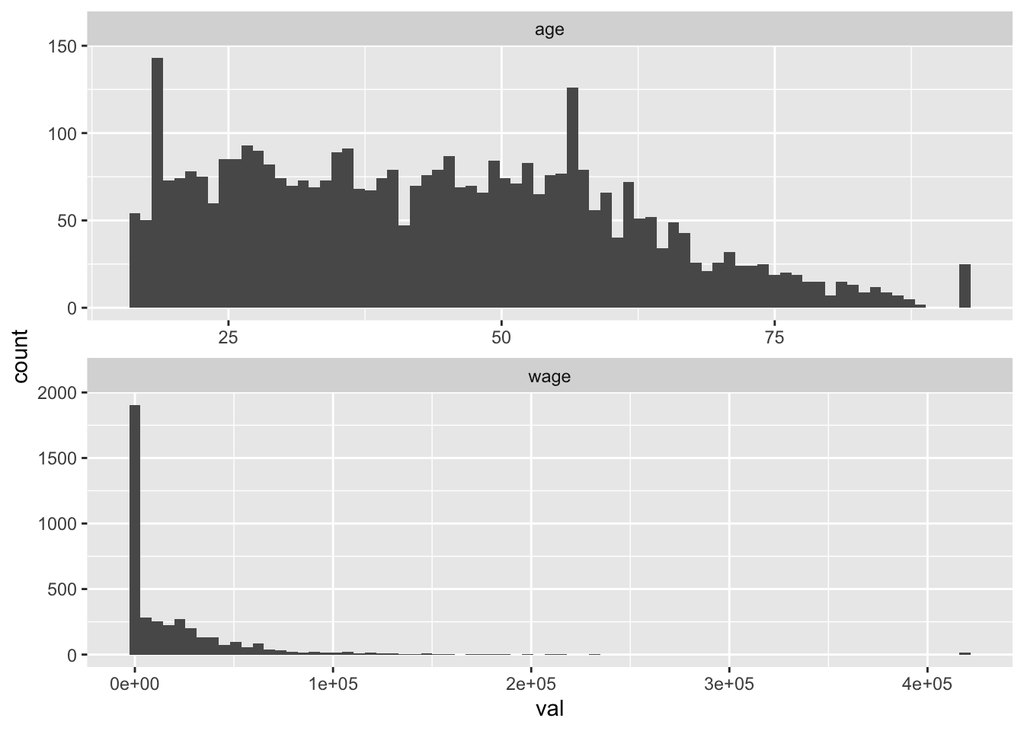

```r
train_data %>%
  select_if(is.numeric) %>%
  gather(var,val) %>%
  ggplot(aes(val)) +
  geom_histogram(bins = 75) +
  facet_wrap(~var,scales="free",ncol=1)
```

Things to note:

- Wage is right skewed. There appears to an outlier making a lot of the money. This outlier could cause problems.
- Good distribution on the age variable.
- The scales for both these variables will have to be adjusted.

Let’s peek more closely at the distribution of wealth in the sample.

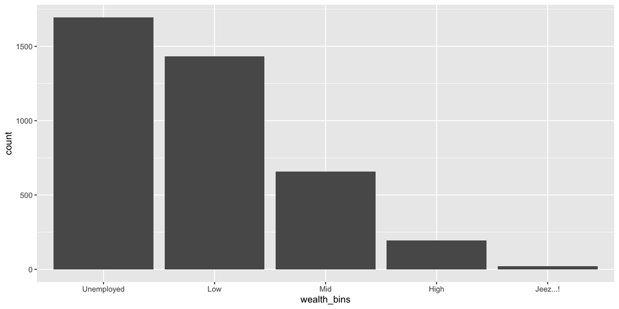

```r
train_data %>%
  mutate(wealth_bins = case_when(
    wage == 0 ~ "Unemployed",
    wage > 0 & wage<= 30000 ~ "Low",
    wage > 30000 & wage<= 75000 ~ "Mid",
    wage > 75000 & wage<= 200000 ~ "High",
    wage > 200000 ~ "Jeez...!",
  )) %>%
  mutate(wealth_bins = fct_infreq(wealth_bins)) %>%
  ggplot(aes(wealth_bins)) +
  geom_bar()
```

There are a lot of individuals that report 0 income (Unemployed?). What is the age distribution for those individuals?

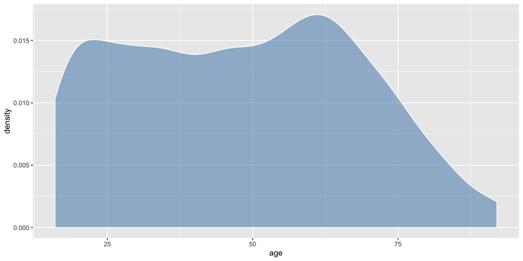

```r
train_data %>%
  filter(wage==0) %>%
  ggplot(aes(age)) +
  geom_density(fill="steelblue",alpha=.5,color="white")
```

# Pre-process the Data

What do we need to do?

- Categorical variables to dummies
- We’ll likely need to log wage to deal with skew.
- Scale age and wage (so that they fall into a 0 to 1 range)
- No need to impute missing values. All the data is there.

First, convert the wage scale.

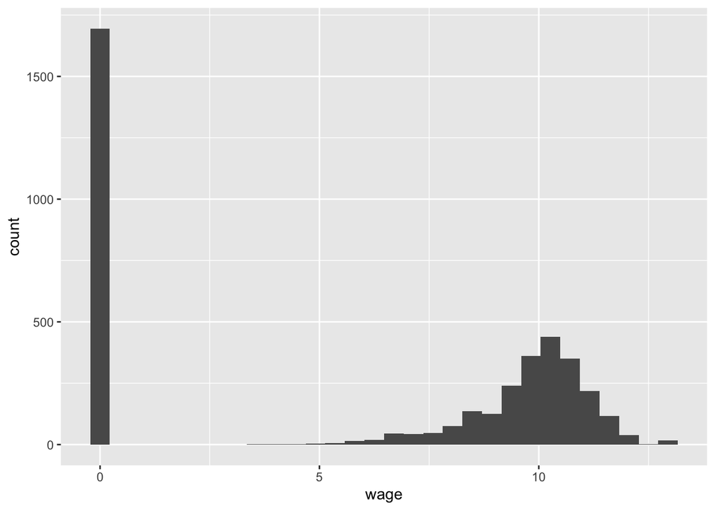

```r
# Mutate the features
convert_wage <- . %>% mutate(#employed = ifelse(wage==0,"yes","no"),
                             wage = log(wage+1))

# Apply to both the training and test data
train_data2 <- train_data %>%  convert_wage()
test_data2 <- test_data %>%  convert_wage()

# Visualize the transformation
train_data2 %>%
  ggplot(aes(wage)) +
  geom_histogram()
```

```r
rcp <-
  recipe(coverage ~  .,train_data2) %>%
  step_dummy(all_nominal(),-all_outcomes()) %>% # Why exclude outcomes?
  step_range(all_numeric()) %>%  # Normalize scale
  prep()


# Apply the recipe to the training and test data
train_data3 <- bake(rcp,train_data2)
test_data3 <- bake(rcp,test_data2)
```

Check that our pre-processing worked.

```r
head(train_data3)
```

```
## # A tibble: 6 x 18
##   coverage   age  wage cit_Non.citizen mar_Married mar_Never.Marri…
##   <fct>    <dbl> <dbl>           <dbl>       <dbl>            <dbl>
## 1 Coverage 0.263 0.903               1           1                0
## 2 No_Cove… 0.342 0                   0           0                1
## 3 Coverage 0.592 0.851               0           1                0
## 4 Coverage 0.763 0                   0           0                0
## 5 No_Cove… 0.263 0.782               0           1                0
## 6 Coverage 0.145 0.788               0           1                0
## # … with 12 more variables: mar_Separated <dbl>, mar_Widowed <dbl>,
## #   educ_HS.Degree <dbl>, educ_Less.than.HS <dbl>,
## #   educ_Undergraduate.Degree <dbl>, race_Asian <dbl>, race_Black <dbl>,
## #   race_Nat..Hawaiian.Pac..Isl. <dbl>, race_Other <dbl>,
## #   race_Tribes.Spec. <dbl>, race_Two.or.More <dbl>, race_White <dbl>
```

[figure not shown]

```r
train_data3 %>%
  select(wage,age) %>%
  gather(var,val) %>%
  ggplot(aes(val)) +
  geom_histogram(bins = 75) +
  facet_wrap(~var,scales="free",ncol=1)
```

# Cross-validation

When comparing different machine learning models, we want to make sure we’re making a fair and equal comparison. One way that random chance can sneak into our assessments of model fit is through cross-validation. We want to make sure that we’re cross-validating the data on the exact same data partitions.

```r
set.seed(1988) # set a seed for replication purposes

folds <- createFolds(train_data3$coverage, k = 5) # Partition the data into 10 equal folds

sapply(folds,length)
```

```
## Fold1 Fold2 Fold3 Fold4 Fold5
##   800   801   800   801   799
```

Now, let’s use the `trainControl()` function from `caret` to set up our validation conditions. An important changes from last week: we have to tell `caret` that we are dealing with a classification problem. We can do this by adding `summaryFunction = twoClassSummary` and `classProbs = TRUE` to the cross-validation function.

```r
control_conditions <-
  trainControl(method='cv', # K-fold cross validation
               summaryFunction = twoClassSummary, # Need this b/c it's a classification problem
               classProbs = TRUE, # Need this b/c it's a classification problem
               index = folds # The indices for our folds (so they are always the same)
  )
```

We’ll now use this same cross-validation object for everything that we do.

# Models

Let’s explore the different models that we covered in the lecture using the same package framework. As we saw last time in class, `caret` facilitates this task nicely.

## Logistic Regression

Recall we have issues with some of the variable categories (i.e. do to insufficient variation), so we’ll use a retricted model here and just include _some_of the variables.

```r
mod_logit <-
  train(coverage ~ age + wage + cit_Non.citizen + educ_HS.Degree +
          educ_Less.than.HS + educ_Undergraduate.Degree,
        data=train_data3, # Training data
        method = "glm", # logit function
        metric = "ROC", # area under the curve
        trControl = control_conditions
  )
mod_logit
```

```
## Generalized Linear Model
##
## 4001 samples
##    6 predictor
##    2 classes: 'Coverage', 'No_Coverage'
##
## No pre-processing
## Resampling: Cross-Validated (10 fold)
## Summary of sample sizes: 800, 801, 800, 801, 799
## Resampling results:
##
##   ROC        Sens       Spec
##   0.7624066  0.7101839  0.6896924
```

## K-Nearest Neighbors

> Remember: these algorithms are computationally demanding, so they can take a little time to run depending on the power of your machine

```r
mod_knn <-
  train(coverage ~ ., # Equation (outcome and everything else)
        data=train_data3, # Training data
        method = "knn", # K-Nearest Neighbors Algorithm
        metric = "ROC", # area under the curve
        trControl = control_conditions
  )
```

Let’s look at the performance plots. What do we see?

```r
mod_knn
```

```
## k-Nearest Neighbors
##
## 4001 samples
##   17 predictor
##    2 classes: 'Coverage', 'No_Coverage'
##
## No pre-processing
## Resampling: Cross-Validated (10 fold)
## Summary of sample sizes: 800, 801, 800, 801, 799
## Resampling results across tuning parameters:
##
##   k  ROC        Sens       Spec
##   5  0.7720196  0.6945841  0.7267291
##   7  0.7755686  0.6883409  0.7296063
##   9  0.7759345  0.6887156  0.7324828
##
## ROC was used to select the optimal model using the largest value.
## The final value used for the model was k = 9.
```

- `caret` has default settings that auto explore different tunning parameters for the model.
- We can easily plot these tuning features using the standard plot functions (these function have been over-ridden in R)

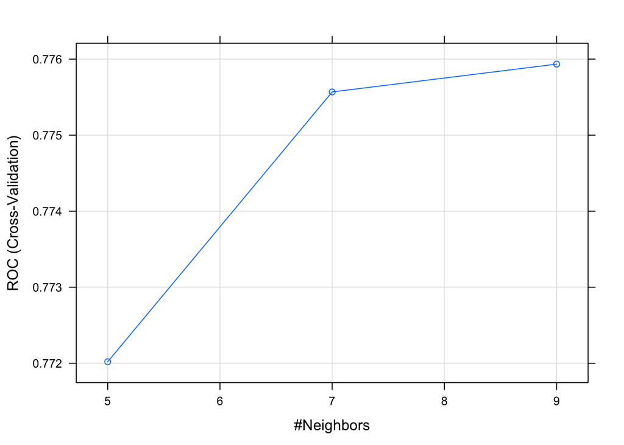

```r
plot(mod_knn)
```

Now, let’s say we wanted to adjust the tunning parameters. We can explore different model tunings by using the `tuneGrid` argument.

```r
knn_tune = expand.grid(k = c(1,3,10,50))
knn_tune
```

```
##    k
## 1  1
## 2  3
## 3 10
## 4 50
```

```r
mod_knn2 <-
  train(coverage ~ ., # Equation (outcome and everything else)
        data=train_data3, # Training data
        method = "knn", # K-Nearest Neighbors Algorithm
        metric = "ROC", # area under the curve
        tuneGrid = knn_tune, # add the tuning parameters here
        trControl = control_conditions
  )
```

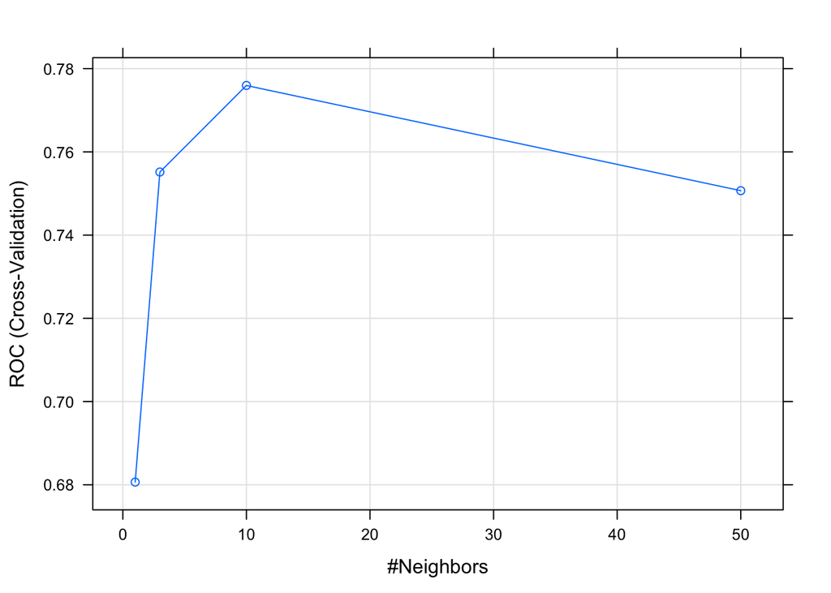

```r
plot(mod_knn2)
```

## Classification and Regression Trees (CART)

```r
mod_cart <-
  train(coverage ~ ., # Equation (outcome and everything else)
        data=train_data3, # Training data
        method = "rpart", # Classification Tree
        metric = "ROC", # area under the curve
        trControl = control_conditions
  )
```

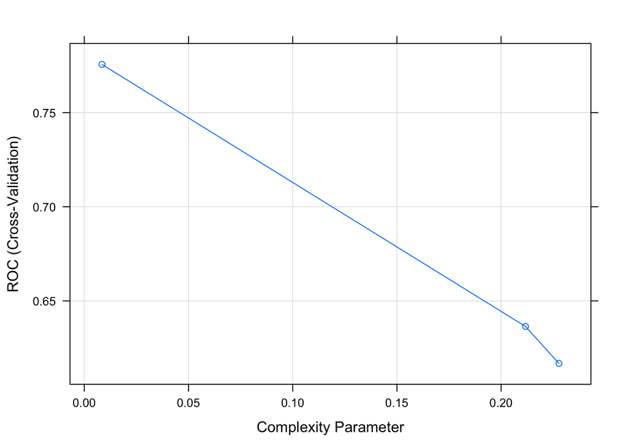

```r
plot(mod_cart)
```

Shallower trees converge to a coin flip. The deepest tree appears to be the bets

Let’s visualize the decision tree…

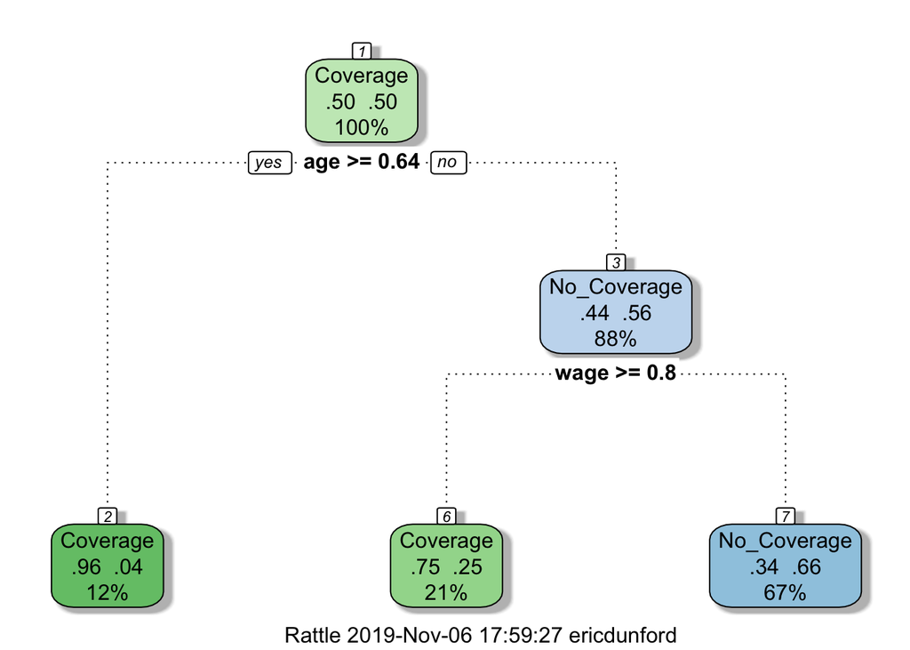

```r
# This tree goes really deep
fancyRpartPlot(mod_cart$finalModel)
```

```r
print(mod_cart$finalModel)
```

```
## n= 4001
##
## node), split, n, loss, yval, (yprob)
##       * denotes terminal node
##
## 1) root 4001 1998 Coverage (0.50062484 0.49937516)
##   2) age>=0.6381579 496   18 Coverage (0.96370968 0.03629032) *
##   3) age< 0.6381579 3505 1525 No_Coverage (0.43509272 0.56490728)
##     6) wage>=0.7984867 833  205 Coverage (0.75390156 0.24609844) *
##     7) wage< 0.7984867 2672  897 No_Coverage (0.33570359 0.66429641) *
```

Let’s free the CART to grow deeper

```r
tune_cart2 <- expand.grid(cp = c(0.0010281)) # Complexity Parameter (how "deep" our trees should grow)
mod_cart2 <-
  train(coverage ~ ., # Equation (outcome and everything else)
        data=train_data3, # Training data
        method = "rpart", # Classification Tree
        metric = "ROC", # area under the curve
        tuneGrid = tune_cart2, # Tuning parameters
        trControl = control_conditions
  )
```

The Model becomes far more complex!

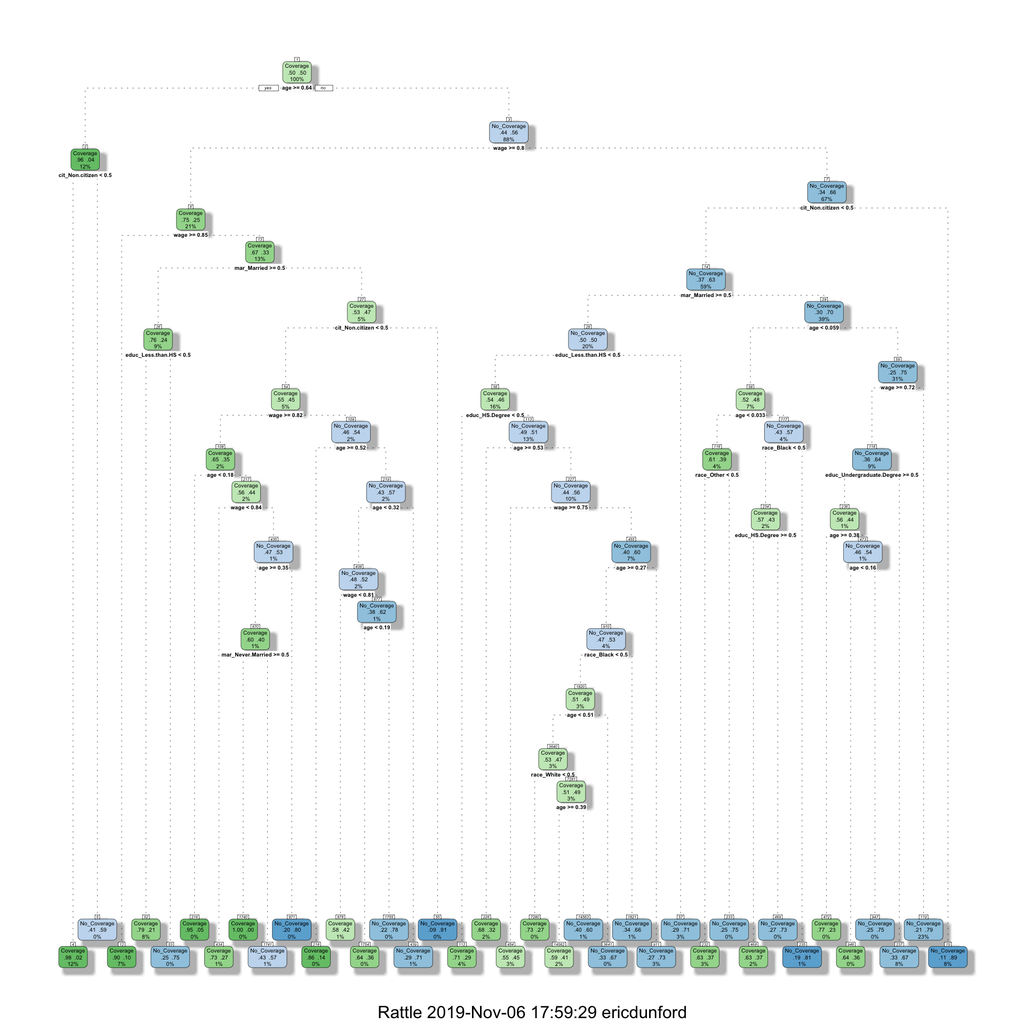

```r
fancyRpartPlot(mod_cart2$finalModel)
```

## Random Forest

```r
mod_rf <-
  train(coverage ~ ., # Equation (outcome and everything else)
        data=train_data3, # Training data
        method = "ranger", # random forest (ranger is much faster than rf)
        metric = "ROC", # area under the curve
        trControl = control_conditions
  )
```

There are three tunning parameters in this model:

- `mtry`: the number of predictors that we’ll randomly select.
- `splitrule`: the way we determine how the nodes should be split
  - `gini` = node purity (see class lecture)
  - `extratrees` = doesn’t bag, randomly select vars, but just randomly split, accept the best split. (Short for “Extremely Randomize Trees”)
- ‘min.node.size’: the minimum number of observations that can be in each terminal node (default fixes this at 1)

```r
mod_rf
```

```
## Random Forest
##
## 4001 samples
##   17 predictor
##    2 classes: 'Coverage', 'No_Coverage'
##
## No pre-processing
## Resampling: Cross-Validated (10 fold)
## Summary of sample sizes: 800, 801, 800, 801, 799
## Resampling results across tuning parameters:
##
##   mtry  splitrule   ROC        Sens       Spec
##    2    gini        0.8213543  0.7026954  0.7820352
##    2    extratrees  0.7887199  0.7181715  0.7261028
##    9    gini        0.8114496  0.7075644  0.7543794
##    9    extratrees  0.8121704  0.7046927  0.7567589
##   17    gini        0.7978598  0.7051934  0.7397396
##   17    extratrees  0.7964852  0.7058169  0.7374864
##
## Tuning parameter 'min.node.size' was held constant at a value of 1
## ROC was used to select the optimal model using the largest value.
## The final values used for the model were mtry = 2, splitrule = gini
##  and min.node.size = 1.
```

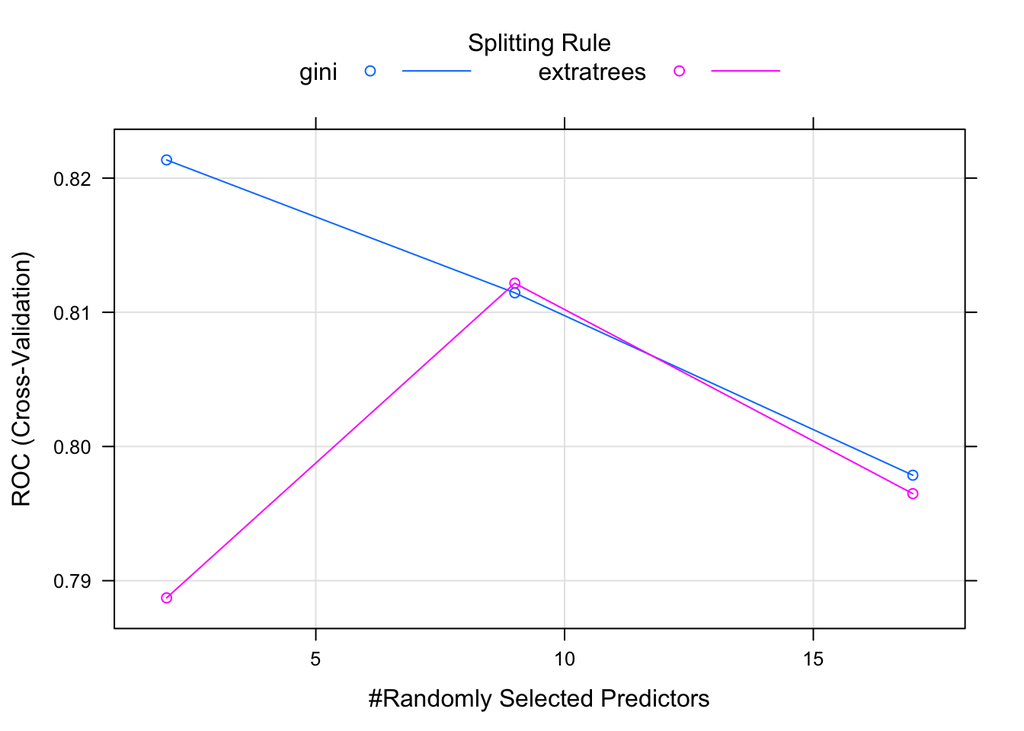

```r
plot(mod_rf)
```

## Support Vector Machine

### Linear Boundary

```r
mod_svm_linear <-
  train(coverage ~ age + wage + cit_Non.citizen + educ_HS.Degree +
          educ_Less.than.HS + educ_Undergraduate.Degree,
        data=train_data3, # Training data
         method = "svmLinear", # SVM with a polynomial Kernel
        metric = "ROC", # area under the curve
        tuneGrid = expand.grid(C = c(.5,1)), # Add two tuning parameters
        trControl = control_conditions
  )
```

```r
mod_svm_linear
```

```
## Support Vector Machines with Linear Kernel
##
## 4001 samples
##    6 predictor
##    2 classes: 'Coverage', 'No_Coverage'
##
## No pre-processing
## Resampling: Cross-Validated (10 fold)
## Summary of sample sizes: 800, 801, 800, 801, 799
## Resampling results across tuning parameters:
##
##   C    ROC        Sens       Spec
##   0.5  0.7616716  0.7111835  0.6871883
##   1.0  0.7617223  0.7111830  0.6870637
##
## ROC was used to select the optimal model using the largest value.
## The final value used for the model was C = 1.
```

### Polynomial Boundary

```r
mod_svm_poly <-
  train(coverage ~ age + wage + cit_Non.citizen + educ_HS.Degree +
          educ_Less.than.HS + educ_Undergraduate.Degree,
        data=train_data3, # Training data
         method = "svmPoly", # SVM with a polynomial Kernel
        metric = "ROC", # area under the curve
        trControl = control_conditions
  )
```

```r
mod_svm_poly
```

```
## Support Vector Machines with Polynomial Kernel
##
## 4001 samples
##    6 predictor
##    2 classes: 'Coverage', 'No_Coverage'
##
## No pre-processing
## Resampling: Cross-Validated (10 fold)
## Summary of sample sizes: 800, 801, 800, 801, 799
## Resampling results across tuning parameters:
##
##   degree  scale  C     ROC        Sens       Spec
##   1       0.001  0.25  0.7531308  0.8403546  0.2967589
##   1       0.001  0.50  0.7531308  0.7660987  0.5161067
##   1       0.001  1.00  0.7534808  0.6588867  0.7234593
```

[output cut: 27 more lines]

```r
mod_svm_radial <-
  train(coverage ~ age + wage + cit_Non.citizen + educ_HS.Degree +
          educ_Less.than.HS + educ_Undergraduate.Degree,
        data=train_data3, # Training data
         method = "svmPoly", # SVM with a Radial Kernel
        metric = "ROC", # area under the curve
        trControl = control_conditions
  )
```

```r
mod_svm_radial
```

```
## Support Vector Machines with Polynomial Kernel
##
## 4001 samples
##    6 predictor
##    2 classes: 'Coverage', 'No_Coverage'
##
## No pre-processing
## Resampling: Cross-Validated (10 fold)
## Summary of sample sizes: 800, 801, 800, 801, 799
## Resampling results across tuning parameters:
##
##   degree  scale  C     ROC        Sens       Spec
##   1       0.001  0.25  0.7531308  0.8406078  0.3042703
##   1       0.001  0.50  0.7531308  0.7770765  0.5027134
##   1       0.001  1.00  0.7534808  0.6697463  0.7101981
```

[output cut: 27 more lines]

# Model Comparison

How did the different methods perform? Which one did the best?

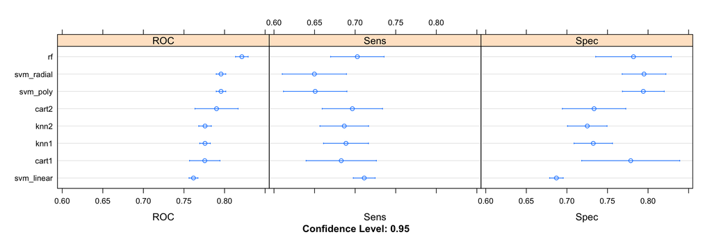

```r
# Organize all model imputs as a list.
mod_list <-
  list(
    knn1 = mod_knn,
    knn2 = mod_knn2,
    cart1 = mod_cart,
    cart2 = mod_cart2,
    rf = mod_rf,
    svm_linear = mod_svm_linear,
    svm_poly = mod_svm_poly,
    svm_radial = mod_svm_radial
  )

# Generate Plot to compare output.
dotplot(resamples(mod_list))
```

# Predictive Performance

Examine the predictive performance of the best performing model.

```r
pred <- predict(mod_rf,newdata = test_data3)
confusionMatrix(table(pred,test_data3$coverage))
```

```
## Confusion Matrix and Statistics
##
##
## pred          Coverage No_Coverage
##   Coverage         347         116
##   No_Coverage      153         383
##
##                Accuracy : 0.7307
##                  95% CI : (0.7021, 0.758)
##     No Information Rate : 0.5005
##     P-Value [Acc > NIR] : < 2e-16
##
##                   Kappa : 0.4615
##  Mcnemar's Test P-Value : 0.02817
##
##             Sensitivity : 0.6940
##             Specificity : 0.7675
##          Pos Pred Value : 0.7495
##          Neg Pred Value : 0.7146
##              Prevalence : 0.5005
##          Detection Rate : 0.3473
##    Detection Prevalence : 0.4635
##       Balanced Accuracy : 0.7308
##
##        'Positive' Class : Coverage
##
```